# 20190924

# chapter 8 ggplot2

We will be creating plots using the ggplot2 package.

```r
library(dplyr)
library(ggplot2)
```

There are also other packages for creating graphics such as grid and lattice. We chose to use **ggplot2** in this book because it breaks plots into components in a way that permits beginners to create relatively complex and aesthetically pleasing plots using syntax that is intuitive and comparatively easy to remember. - it uses a grammar of graphics, the gg in ggplot2. - its default behavior is carefully chosen to satisfy the great majority of cases and is visually pleasing.

One limitation is that ggplot2 is designed to work exclusively with data tables in tidy format (where rows are observations and columns are variables).

## 8.1 The components of a graph

```r
library(dslabs)
data("murders")
```

## 8.2 `ggplot` objects

The first step in creating a ggplot2 graph is to define a `ggplot` object. We do this with the function `ggplot`, which initializes the graph. -> the first argument is used to specify what data is associated with this object or We can also pipe the data in as the first argument. :

```r
ggplot(data = murders)
```

```r
murders %>% ggplot()
```

```r
p <- ggplot(data = murders)
class(p)
```

```
[1] "gg"     "ggplot"
```

```r
print(p)
```

```r
p
```

## 8.3 Geometries

In `ggplot2` we create graphs by adding *layers*. Layers can define geometries, compute summary statistics, define what scales to use, or even change styles. To add layers, we use the the symbol `+`. In general, a line of code will look like this:

```r
DATA %>% ggplot() + LAYER 1 + LAYER 2 + … + LAYER N
```

Usually, the first added layer defines the geometry. We want to make a scatterplot. What geometry do we use? Take a look at the cheat sheep using `geon_point`.

Geometry function names follow the pattern: `geom_X` where X is the name of the geometry. Some examples include `geom_point`, `geom_bar` and `geom_histogram.`

For geom_point to run properly we need to provide data and a mapping. We have already connected the object p with the murders data table, and if we add the layer geom_point it defaults to using this data. And by unsing Asenthetics, at least two arguments are required x and y.

## 8.4 Aesthetic mappings

**Aesthetic mappings** describe how properties of the data connect with features of the graph, such as distance along an axis, size or color.

The `aes` function connects data with the graph by defining aesthetic mappings.

The outcome of the `aes` function = the argument of a geometry function.

This example produces a scatterplot of total murders versus population in millions:

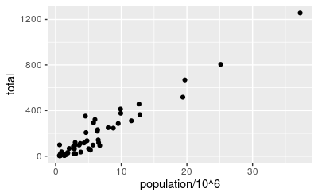

Drop the x = and y = if we wanted to since these are the first and second expected arguments.

Instead of defining our plot from scratch, we can also add a layer to the p object that was defined above as p <- ggplot(data = murders):

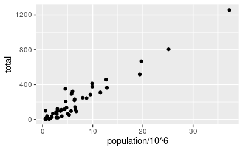

Inside of `aes` function, `population` and `total` means data of murders automatically, but outside of `aes`, you receive an error.

## 8.5 Layers

A second layer in the plot: make involves adding a label to each point to identify the state.

The `geom_label` and `geom_text` functions: add text to the plot with and without a rectangle behind the text respectively.

Because each point (each state in this case) has a label, we need an aesthetic mapping to make the connection between points and labels. We supply the mapping between point and label through the label argument of `aes`. So the code looks like this:

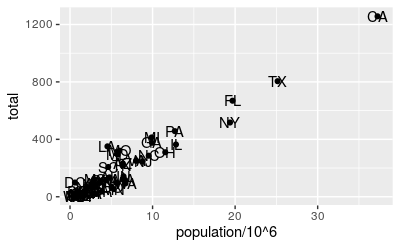

### 8.5.1 Thinkering with arguments

Many arguments in geomatry function is specific to the function.

For example, in the plot we wish to make, the points are larger than the default size In the help file we see that size is an aesthetic and we can change it like this:

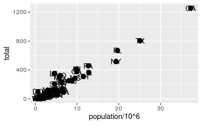

`size` is not a mapping: - mappings use data from specific observations and need to be inside `aes`() - operations we want to affect all the points the same way do not need to be included inside `aes.`

`nudge_x` argument, which moves the text slightly to the right or to the left:

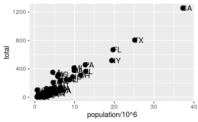

```r
p + geom_point(aes(population/10^6, total), size = 3) +
  geom_text(aes(population/10^6, total, label = abb), nudge_x = 1)
```

# 8.6 Global versus local aesthetic mappings

We can avoid defining the mapping `aes(population/10^6, total)` twice, once in each geometry by using a global aesthetic mapping.

We can do this when we define the blank slate `ggplot` object. Remember that the function `ggplot` contains an argument that permits us to define aesthetic mappings:

```r
args(ggplot)
```

```
function (data = NULL, mapping = aes(), ..., environment = parent.frame())
NULL
```

If we define a mapping in `ggplot`, all the geometries that are added as layers will default to this mapping. We redefine `p`:

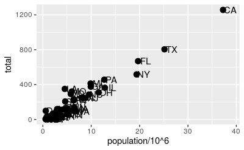

```r
p <- murders %>% ggplot(aes(population/10^6, total, label = abb))
p + geom_point(size = 3) +
  geom_text(nudge_x = 1.5)
```

`geom_point` function does not need a `label` argument and therefore ignores that aesthetic.

If necessary, we can override the global mapping by defining a new mapping within each layer. These local definitions override the global. Here is an example:

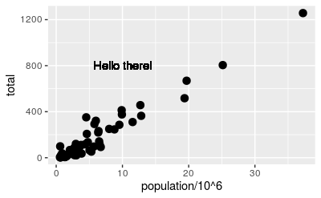

Clearly, the second call to geom_text does not use population and total.

# 8.7 Scales

First, our desired scales are in log-scale. This is not the default, so this change needs to be added through a scales layer.

The `scale_x_continuous` function lets us control the behavior of scales. We use them like this:

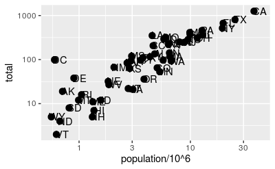

Because we are in the log-scale now, the nudge must be made smaller.

ggplot2 provides the specialized functions `scale_x_log10` and `scale_y_log10`, which we can use to rewrite the code like this:

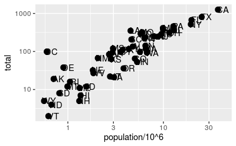

# 8.8 Labels and titles

To change labels and add a title, we use the following functions:

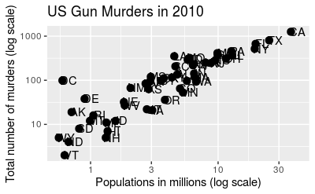

# 8.9 Categories as colors

We can change the color of the points using the `col` argument in the `geom_point` function

we will redefine p to be everything except the points layer: We can make all the points blue by adding the color argument:

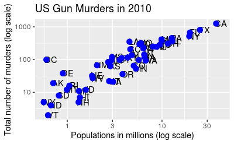

```r
p <-  murders %>% ggplot(aes(population/10^6, total, label = abb)) +
  geom_text(nudge_x = 0.05) +
  scale_x_log10() +
  scale_y_log10() +
  xlab("Populations in millions (log scale)") +
  ylab("Total number of murders (log scale)") +
  ggtitle("US Gun Murders in 2010")
p + geom_point(size = 3, color ="blue")
```

We want not this but to assign color depending on the geographical region.

If we assign a categorical variable to color, it automatically assigns a different color to each category and also adds a legend.

Since the choice of color is determined by a feature of each observation, this is an aesthetic mapping. To map each point to a color, we need to use `aes.` We use the following code:

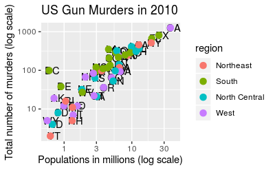

ggplot2 automatically adds a legend that maps color to region. To avoid adding this legend we set the `geom_point` argument `show.legend = FALSE`.

# 8.10 Annotation, shapes, and adjustments